# Understanding distributions

Data Science for Biologists, Spring 2022

## The full dataset

Consider the following dataset called [`penguins`](https://github.com/allisonhorst/palmerpenguins), a dataset of 344 individual penguins collected and made available by Dr. Kristen Gorman and the Palmer Station, Antarctica LTER, a member of the Long Term Ecological Research Network.

|  | species | island | bill_length_mm | bill_depth_mm | flipper_length_mm | body_mass_g | sex | year |
| --- | --- | --- | --- | --- | --- | --- | --- | --- |
| 1 | Adelie | Torgersen | 39.1 | 18.7 | 181 | 3750 | male | 2007 |
| 2 | Adelie | Torgersen | 39.5 | 17.4 | 186 | 3800 | female | 2007 |
| 3 | Adelie | Torgersen | 40.3 | 18 | 195 | 3250 | female | 2007 |
| 4 | Adelie | Torgersen | NA | NA | NA | NA | NA | 2007 |
| 5 | Adelie | Torgersen | 36.7 | 19.3 | 193 | 3450 | female | 2007 |
| 6 | Adelie | Torgersen | 39.3 | 20.6 | 190 | 3650 | male | 2007 |
| 7 | Adelie | Torgersen | 38.9 | 17.8 | 181 | 3625 | female | 2007 |
| 8 | Adelie | Torgersen | 39.2 | 19.6 | 195 | 4675 | male | 2007 |
| 9 | Adelie | Torgersen | 34.1 | 18.1 | 193 | 3475 | NA | 2007 |
| 10 | Adelie | Torgersen | 42 | 20.2 | 190 | 4250 | NA | 2007 |

[output cut: 334 more lines]

### Questions:

Explore the dataset to determine which columns, aka *dataset variables* contain numeric data and which contain categorical data.

- The numeric columns are:
- The categorical columns are:
- One column could be considered *either* categorical or numeric. Which one?

**Broadly speaking** there are two ways we can examine data. We can either look at the full data, or we can look at summaries of the data. These are both important approaches that complement each other - summarizing shows overall properties but can hide nuances. For both approaches, we can directly look at data (numbers or written information), or we can look at *visualizations* (figures!) to build a sense of the data.

## Exploring numeric distributions

This section explores the dataset variable `flipper_length_mm`, which is a *numeric dataset variable*.

### What can we ask about numeric data?

- We can calculate *summary statistics* to summarize the full data in only a few values
  - What is the *mean* of the distribution?
  - What is the *median* of the distribution?
  - What is the *spread* of the distribution? This is commonly quantified with *standard deviation*.
  - What is the *range* of the distribution (minimum and maximum values)?
  - While these quantities give an overall sense of the data, they often fail to tell you about the *shape* of the distribution!!
- We can also explore the distribution in full by examining its *shape*. Summary statistics often cannot tell us anything about shape.
  - It is symmetric or skewed?
  - It is unimodal? Bimodal? Multimodal?

### 1: Look at the literal data

Often, you can get an overall sense of the values by looking at them directly. Below are printed all 344 flipper lengths from this dataset:

```
##   [1] 181 186 195  NA 193 190 181 195 193 190 186 180 182 191 198 185 195 197
##  [19] 184 194 174 180 189 185 180 187 183 187 172 180 178 178 188 184 195 196
##  [37] 190 180 181 184 182 195 186 196 185 190 182 179 190 191 186 188 190 200
##  [55] 187 191 186 193 181 194 185 195 185 192 184 192 195 188 190 198 190 190
##  [73] 196 197 190 195 191 184 187 195 189 196 187 193 191 194 190 189 189 190
##  [91] 202 205 185 186 187 208 190 196 178 192 192 203 183 190 193 184 199 190
## [109] 181 197 198 191 193 197 191 196 188 199 189 189 187 198 176 202 186 199
## [127] 191 195 191 210 190 197 193 199 187 190 191 200 185 193 193 187 188 190
## [145] 192 185 190 184 195 193 187 201 211 230 210 218 215 210 211 219 209 215
## [163] 214 216 214 213 210 217 210 221 209 222 218 215 213 215 215 215 216 215
## [181] 210 220 222 209 207 230 220 220 213 219 208 208 208 225 210 216 222 217
## [199] 210 225 213 215 210 220 210 225 217 220 208 220 208 224 208 221 214 231
## [217] 219 230 214 229 220 223 216 221 221 217 216 230 209 220 215 223 212 221
## [235] 212 224 212 228 218 218 212 230 218 228 212 224 214 226 216 222 203 225
## [253] 219 228 215 228 216 215 210 219 208 209 216 229 213 230 217 230 217 222
## [271] 214  NA 215 222 212 213 192 196 193 188 197 198 178 197 195 198 193 194
## [289] 185 201 190 201 197 181 190 195 181 191 187 193 195 197 200 200 191 205
## [307] 187 201 187 203 195 199 195 210 192 205 210 187 196 196 196 201 190 212
## [325] 187 198 199 201 193 203 187 197 191 203 202 194 206 189 195 207 202 193
## [343] 210 198
```

That’s a lot! Imagine if we had 5,000,000 (getting close to “big data”) rows instead of only 344. We definitely couldn’t look at all of those numbers **(but, some of them aren’t numbers - what are they?)**

### 2: Determine summaries of the dataset

- The **mean** is 200.92.
- The **median** is 197.
- The **standard deviation** is 14.06.
- The **range** is [172, 231].
  - AKA, the **minimum** is 172 and the **maximum** is 231.

### 3: Visualize the data

#### Histograms visualize *binned* numeric distributions

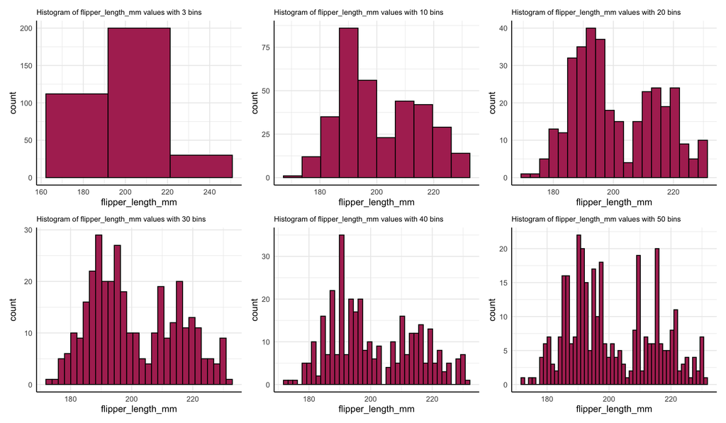

#### Density plots are like “smooth” histograms whose interpretation is not affected by binning, since there are no bins!

- We IGNORE the values on the Y-axis (the density values of 0.01, 0.02, etc. are *meaningless*).
- We interpret it based on TRENDS:
  - More area under the curve = more values in that region of the x-axis

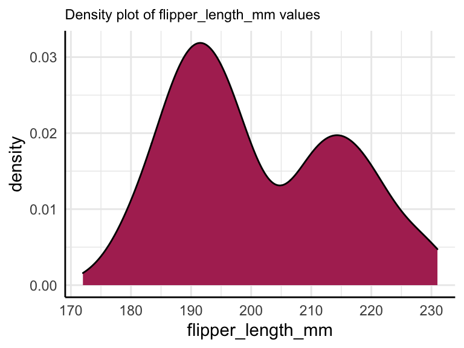

Here is the same density plot but with a “point rug,” literally a “rug” of the data points along the x-axis number line. Notice how the density graph is “taller” (more area under curve!) where there are more points, and it dips lower when there are fewer points in that region on the x-axis.

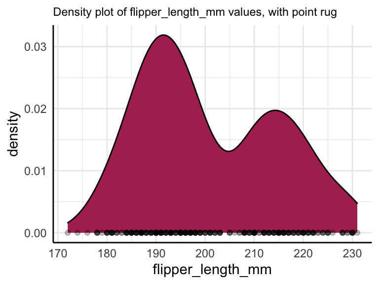

#### Boxplots visualize data using summary statistics

- Boxplots were invented because you can draw them by hand!
- The “box” is the *interquartile range*, representing the boundaries of the middle 50% of the data
- The line in the box is the **median** (50% of the data is above and below)
- The “whiskers” represent (usually) the range of data that is within 150% of the IQR (but there are other ways!)
  - Often this equates to minimum and maximum, but sometimes there are “outliers.” This boxplot does not contain any outliers.

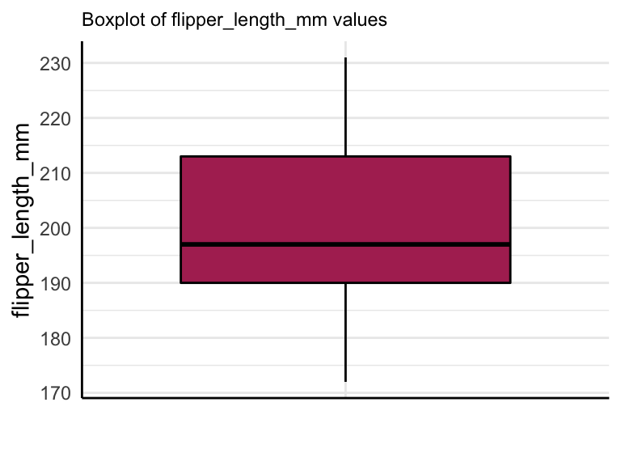

#### Violin plots are “sideways mirrored” density plots

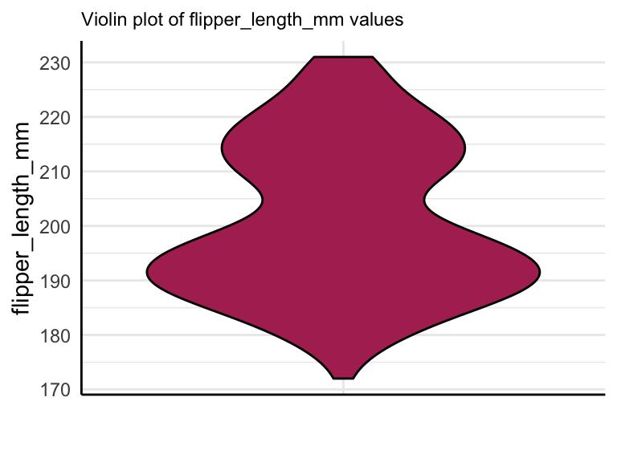

### 4: Visualize distributions *across* groupings.

We can also explore the distribution of `flipper_length_mm` values **across** a categorical dataset variable, such as `species`. To compare distributions, it is very common to use *overlapping* density plots, boxplots, and violin plots. Generally we avoid histograms when *comparing* distributions.

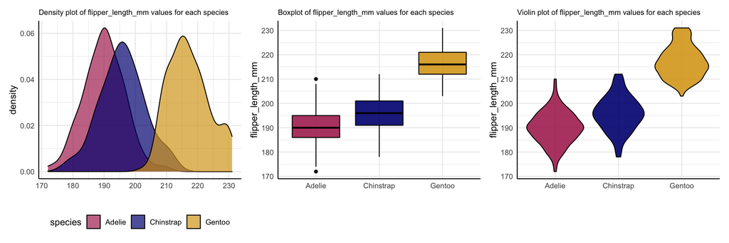

## Exploring categorical distributions